# Risk Factor Analysis

## Outcome Variable

**Outcome Variable:** ever_co

## Predictor Variables

**Intervention Variable:** exclfeed6

**Adjustment Set:**

- arm
- sex
- W_mage
- meducyrs
- feducyrs
- hhwealth_quart
- hfoodsec
- W_mhtcm
- vagbrth
- W_gagebrth
- W_birthwt
- W_birthlen
- W_nrooms
- W_nchldlt5
- month
- brthmon
- W_parity
- impfloor
- impsan
- safeh20
- delta_W_mage
- delta_meducyrs
- delta_feducyrs
- delta_hhwealth_quart
- delta_hfoodsec
- delta_W_mhtcm
- delta_vagbrth
- delta_W_gagebrth
- delta_W_birthwt
- delta_W_birthlen
- delta_W_nrooms
- delta_W_nchldlt5
- delta_month
- delta_brthmon
- delta_W_parity
- delta_impfloor
- delta_impsan
- delta_safeh20

## Stratifying Variables

The analysis was stratified on these variable(s):

- agecat
- studyid
- country

## Data Summary

| agecat | studyid | country | exclfeed6 | ever_co | n_cell | n |
| --- | --- | --- | --- | --- | --- | --- |
| 0-24 months | ki0047075b-MAL-ED | BANGLADESH | 1 | 0 | 44 | 238 |
| 0-24 months | ki0047075b-MAL-ED | BANGLADESH | 1 | 1 | 14 | 238 |
| 0-24 months | ki0047075b-MAL-ED | BANGLADESH | 0 | 0 | 155 | 238 |
| 0-24 months | ki0047075b-MAL-ED | BANGLADESH | 0 | 1 | 25 | 238 |
| 0-24 months | ki0047075b-MAL-ED | BRAZIL | 1 | 0 | 17 | 212 |
| 0-24 months | ki0047075b-MAL-ED | BRAZIL | 1 | 1 | 0 | 212 |
| 0-24 months | ki0047075b-MAL-ED | BRAZIL | 0 | 0 | 193 | 212 |
| 0-24 months | ki0047075b-MAL-ED | BRAZIL | 0 | 1 | 2 | 212 |
| 0-24 months | ki0047075b-MAL-ED | INDIA | 1 | 0 | 6 | 234 |
| 0-24 months | ki0047075b-MAL-ED | INDIA | 1 | 1 | 0 | 234 |
| 0-24 months | ki0047075b-MAL-ED | INDIA | 0 | 0 | 176 | 234 |
| 0-24 months | ki0047075b-MAL-ED | INDIA | 0 | 1 | 52 | 234 |
| 0-24 months | ki0047075b-MAL-ED | NEPAL | 1 | 0 | 14 | 235 |
| 0-24 months | ki0047075b-MAL-ED | NEPAL | 1 | 1 | 1 | 235 |
| 0-24 months | ki0047075b-MAL-ED | NEPAL | 0 | 0 | 200 | 235 |
| 0-24 months | ki0047075b-MAL-ED | NEPAL | 0 | 1 | 20 | 235 |
| 0-24 months | ki0047075b-MAL-ED | PERU | 1 | 0 | 11 | 270 |
| 0-24 months | ki0047075b-MAL-ED | PERU | 1 | 1 | 0 | 270 |
| 0-24 months | ki0047075b-MAL-ED | PERU | 0 | 0 | 250 | 270 |
| 0-24 months | ki0047075b-MAL-ED | PERU | 0 | 1 | 9 | 270 |
| 0-24 months | ki0047075b-MAL-ED | SOUTH AFRICA | 1 | 0 | 0 | 248 |
| 0-24 months | ki0047075b-MAL-ED | SOUTH AFRICA | 1 | 1 | 0 | 248 |
| 0-24 months | ki0047075b-MAL-ED | SOUTH AFRICA | 0 | 0 | 227 | 248 |
| 0-24 months | ki0047075b-MAL-ED | SOUTH AFRICA | 0 | 1 | 21 | 248 |
| 0-24 months | ki0047075b-MAL-ED | TANZANIA, UNITED REPUBLIC OF | 1 | 0 | 1 | 248 |
| 0-24 months | ki0047075b-MAL-ED | TANZANIA, UNITED REPUBLIC OF | 1 | 1 | 0 | 248 |
| 0-24 months | ki0047075b-MAL-ED | TANZANIA, UNITED REPUBLIC OF | 0 | 0 | 224 | 248 |
| 0-24 months | ki0047075b-MAL-ED | TANZANIA, UNITED REPUBLIC OF | 0 | 1 | 23 | 248 |
| 0-24 months | ki1000108-CMC-V-BCS-2002 | INDIA | 1 | 0 | 15 | 19 |
| 0-24 months | ki1000108-CMC-V-BCS-2002 | INDIA | 1 | 1 | 4 | 19 |

[output cut: 186 more lines]

The following strata were considered:

- agecat: 0-24 months, studyid: ki0047075b-MAL-ED, country: BANGLADESH
- agecat: 0-24 months, studyid: ki0047075b-MAL-ED, country: BRAZIL
- agecat: 0-24 months, studyid: ki0047075b-MAL-ED, country: INDIA
- agecat: 0-24 months, studyid: ki0047075b-MAL-ED, country: NEPAL
- agecat: 0-24 months, studyid: ki0047075b-MAL-ED, country: PERU
- agecat: 0-24 months, studyid: ki0047075b-MAL-ED, country: SOUTH AFRICA
- agecat: 0-24 months, studyid: ki0047075b-MAL-ED, country: TANZANIA, UNITED REPUBLIC OF
- agecat: 0-24 months, studyid: ki1000108-CMC-V-BCS-2002, country: INDIA
- agecat: 0-24 months, studyid: ki1000108-IRC, country: INDIA
- agecat: 0-24 months, studyid: ki1000109-EE, country: PAKISTAN
- agecat: 0-24 months, studyid: ki1000304b-SAS-CompFeed, country: INDIA
- agecat: 0-24 months, studyid: ki1000304b-SAS-FoodSuppl, country: INDIA
- agecat: 0-24 months, studyid: ki1017093b-PROVIDE, country: BANGLADESH
- agecat: 0-24 months, studyid: ki1101329-Keneba, country: GAMBIA
- agecat: 0-24 months, studyid: ki1113344-GMS-Nepal, country: NEPAL
- agecat: 0-24 months, studyid: ki1148112-LCNI-5, country: MALAWI
- agecat: 0-24 months, studyid: kiGH5241-JiVitA-3, country: BANGLADESH
- agecat: 0-24 months, studyid: kiGH5241-JiVitA-4, country: BANGLADESH
- agecat: 0-6 months, studyid: ki0047075b-MAL-ED, country: BANGLADESH
- agecat: 0-6 months, studyid: ki0047075b-MAL-ED, country: BRAZIL
- agecat: 0-6 months, studyid: ki0047075b-MAL-ED, country: INDIA
- agecat: 0-6 months, studyid: ki0047075b-MAL-ED, country: NEPAL
- agecat: 0-6 months, studyid: ki0047075b-MAL-ED, country: PERU
- agecat: 0-6 months, studyid: ki0047075b-MAL-ED, country: SOUTH AFRICA
- agecat: 0-6 months, studyid: ki0047075b-MAL-ED, country: TANZANIA, UNITED REPUBLIC OF
- agecat: 0-6 months, studyid: ki1000108-CMC-V-BCS-2002, country: INDIA
- agecat: 0-6 months, studyid: ki1000108-IRC, country: INDIA
- agecat: 0-6 months, studyid: ki1000109-EE, country: PAKISTAN
- agecat: 0-6 months, studyid: ki1000304b-SAS-CompFeed, country: INDIA
- agecat: 0-6 months, studyid: ki1000304b-SAS-FoodSuppl, country: INDIA
- agecat: 0-6 months, studyid: ki1017093b-PROVIDE, country: BANGLADESH
- agecat: 0-6 months, studyid: ki1101329-Keneba, country: GAMBIA
- agecat: 0-6 months, studyid: ki1113344-GMS-Nepal, country: NEPAL
- agecat: 0-6 months, studyid: ki1148112-LCNI-5, country: MALAWI
- agecat: 0-6 months, studyid: kiGH5241-JiVitA-3, country: BANGLADESH
- agecat: 0-6 months, studyid: kiGH5241-JiVitA-4, country: BANGLADESH
- agecat: 6-24 months, studyid: ki0047075b-MAL-ED, country: BANGLADESH
- agecat: 6-24 months, studyid: ki0047075b-MAL-ED, country: BRAZIL
- agecat: 6-24 months, studyid: ki0047075b-MAL-ED, country: INDIA
- agecat: 6-24 months, studyid: ki0047075b-MAL-ED, country: NEPAL
- agecat: 6-24 months, studyid: ki0047075b-MAL-ED, country: PERU
- agecat: 6-24 months, studyid: ki0047075b-MAL-ED, country: SOUTH AFRICA
- agecat: 6-24 months, studyid: ki0047075b-MAL-ED, country: TANZANIA, UNITED REPUBLIC OF
- agecat: 6-24 months, studyid: ki1000108-CMC-V-BCS-2002, country: INDIA
- agecat: 6-24 months, studyid: ki1000108-IRC, country: INDIA
- agecat: 6-24 months, studyid: ki1000109-EE, country: PAKISTAN
- agecat: 6-24 months, studyid: ki1000304b-SAS-CompFeed, country: INDIA
- agecat: 6-24 months, studyid: ki1000304b-SAS-FoodSuppl, country: INDIA
- agecat: 6-24 months, studyid: ki1017093b-PROVIDE, country: BANGLADESH
- agecat: 6-24 months, studyid: ki1101329-Keneba, country: GAMBIA
- agecat: 6-24 months, studyid: ki1113344-GMS-Nepal, country: NEPAL
- agecat: 6-24 months, studyid: ki1148112-LCNI-5, country: MALAWI
- agecat: 6-24 months, studyid: kiGH5241-JiVitA-3, country: BANGLADESH
- agecat: 6-24 months, studyid: kiGH5241-JiVitA-4, country: BANGLADESH

### Dropped Strata

Some strata were dropped due to rare outcomes:

- agecat: 0-24 months, studyid: ki0047075b-MAL-ED, country: BRAZIL
- agecat: 0-24 months, studyid: ki0047075b-MAL-ED, country: INDIA
- agecat: 0-24 months, studyid: ki0047075b-MAL-ED, country: NEPAL
- agecat: 0-24 months, studyid: ki0047075b-MAL-ED, country: PERU
- agecat: 0-24 months, studyid: ki0047075b-MAL-ED, country: SOUTH AFRICA
- agecat: 0-24 months, studyid: ki0047075b-MAL-ED, country: TANZANIA, UNITED REPUBLIC OF
- agecat: 0-24 months, studyid: ki1000108-CMC-V-BCS-2002, country: INDIA
- agecat: 0-24 months, studyid: ki1000108-IRC, country: INDIA
- agecat: 0-24 months, studyid: ki1000304b-SAS-FoodSuppl, country: INDIA
- agecat: 0-24 months, studyid: ki1148112-LCNI-5, country: MALAWI
- agecat: 0-6 months, studyid: ki0047075b-MAL-ED, country: BANGLADESH
- agecat: 0-6 months, studyid: ki0047075b-MAL-ED, country: BRAZIL
- agecat: 0-6 months, studyid: ki0047075b-MAL-ED, country: INDIA
- agecat: 0-6 months, studyid: ki0047075b-MAL-ED, country: NEPAL
- agecat: 0-6 months, studyid: ki0047075b-MAL-ED, country: PERU
- agecat: 0-6 months, studyid: ki0047075b-MAL-ED, country: SOUTH AFRICA
- agecat: 0-6 months, studyid: ki0047075b-MAL-ED, country: TANZANIA, UNITED REPUBLIC OF
- agecat: 0-6 months, studyid: ki1000108-CMC-V-BCS-2002, country: INDIA
- agecat: 0-6 months, studyid: ki1000108-IRC, country: INDIA
- agecat: 0-6 months, studyid: ki1000304b-SAS-CompFeed, country: INDIA
- agecat: 0-6 months, studyid: ki1000304b-SAS-FoodSuppl, country: INDIA
- agecat: 0-6 months, studyid: ki1017093b-PROVIDE, country: BANGLADESH
- agecat: 0-6 months, studyid: ki1148112-LCNI-5, country: MALAWI
- agecat: 6-24 months, studyid: ki0047075b-MAL-ED, country: BRAZIL
- agecat: 6-24 months, studyid: ki0047075b-MAL-ED, country: INDIA
- agecat: 6-24 months, studyid: ki0047075b-MAL-ED, country: NEPAL
- agecat: 6-24 months, studyid: ki0047075b-MAL-ED, country: PERU
- agecat: 6-24 months, studyid: ki0047075b-MAL-ED, country: SOUTH AFRICA
- agecat: 6-24 months, studyid: ki0047075b-MAL-ED, country: TANZANIA, UNITED REPUBLIC OF
- agecat: 6-24 months, studyid: ki1000108-CMC-V-BCS-2002, country: INDIA
- agecat: 6-24 months, studyid: ki1000108-IRC, country: INDIA
- agecat: 6-24 months, studyid: ki1000304b-SAS-FoodSuppl, country: INDIA
- agecat: 6-24 months, studyid: ki1148112-LCNI-5, country: MALAWI

## Methods Detail

We’re interested in the causal parameters $E[Y_a]$ for all values of $a \in \mathcal{A}$. These parameters represent the mean outcome if, possibly contrary to fact, we intervened to set all units to have $A=a$. Under the randomization and positivity assumptions, these are identified by the statistical parameters $\psi_a=E_W[E_{Y|A,W}(Y|A=a,W)]$. In addition, we’re interested in the mean of $Y$, $E[Y]$ under no intervention (the observed mean). We will estimate these parameters by using SuperLearner to fit the relevant likelihood factors – $E_{Y|A,W}(Y|A=a,W)$ and $p(A=a|W)$, and then updating our likelihood fit using a joint TMLE.

For unadjusted analyses ($W=\{\}$), initial likelihoods were estimated using Lrnr_glm to estimate the simple $E(Y|A)$ and Lrnr_mean to estimate $p(A)$. For adjusted analyses, a small library containing Lrnr_glmnet, Lrnr_xgboost, and Lrnr_mean was used.

Having estimated these parameters, we will then use the delta method to estimate relative risks and attributable risks relative to a prespecified baseline level of $A$.

# Results Detail

## Results Plots

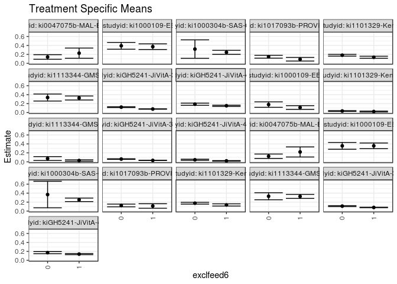

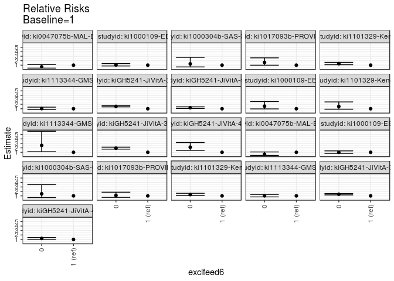

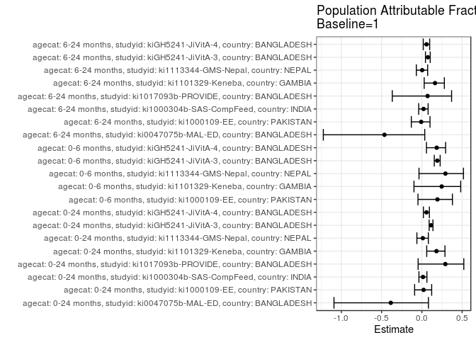

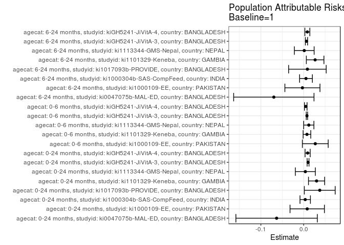

## Results Table

### Parameter: TSM

| agecat | studyid | country | intervention_level | baseline_level | estimate | ci_lower | ci_upper |
| --- | --- | --- | --- | --- | --- | --- | --- |
| 0-24 months | ki0047075b-MAL-ED | BANGLADESH | 1 | NA | 0.2271037 | 0.1133503 | 0.3408570 |
| 0-24 months | ki0047075b-MAL-ED | BANGLADESH | 0 | NA | 0.1417109 | 0.0909252 | 0.1924966 |
| 0-24 months | ki1000109-EE | PAKISTAN | 1 | NA | 0.3717354 | 0.3086865 | 0.4347843 |
| 0-24 months | ki1000109-EE | PAKISTAN | 0 | NA | 0.3911323 | 0.3151584 | 0.4671062 |
| 0-24 months | ki1000304b-SAS-CompFeed | INDIA | 1 | NA | 0.2464455 | 0.2022875 | 0.2906035 |
| 0-24 months | ki1000304b-SAS-CompFeed | INDIA | 0 | NA | 0.3181818 | 0.1124254 | 0.5239382 |
| 0-24 months | ki1017093b-PROVIDE | BANGLADESH | 1 | NA | 0.0910641 | 0.0509386 | 0.1311895 |
| 0-24 months | ki1017093b-PROVIDE | BANGLADESH | 0 | NA | 0.1472365 | 0.1157435 | 0.1787294 |
| 0-24 months | ki1101329-Keneba | GAMBIA | 1 | NA | 0.1359165 | 0.1131322 | 0.1587009 |
| 0-24 months | ki1101329-Keneba | GAMBIA | 0 | NA | 0.1816713 | 0.1618033 | 0.2015393 |
| 0-24 months | ki1113344-GMS-Nepal | NEPAL | 1 | NA | 0.3253265 | 0.2803234 | 0.3703296 |
| 0-24 months | ki1113344-GMS-Nepal | NEPAL | 0 | NA | 0.3361069 | 0.2578534 | 0.4143604 |
| 0-24 months | kiGH5241-JiVitA-3 | BANGLADESH | 1 | NA | 0.0791401 | 0.0750512 | 0.0832290 |
| 0-24 months | kiGH5241-JiVitA-3 | BANGLADESH | 0 | NA | 0.1211489 | 0.1124662 | 0.1298315 |
| 0-24 months | kiGH5241-JiVitA-4 | BANGLADESH | 1 | NA | 0.1523996 | 0.1391759 | 0.1656233 |
| 0-24 months | kiGH5241-JiVitA-4 | BANGLADESH | 0 | NA | 0.1869358 | 0.1629450 | 0.2109266 |
| 0-6 months | ki1000109-EE | PAKISTAN | 1 | NA | 0.1128005 | 0.0714735 | 0.1541275 |
| 0-6 months | ki1000109-EE | PAKISTAN | 0 | NA | 0.1784974 | 0.1178986 | 0.2390962 |
| 0-6 months | ki1101329-Keneba | GAMBIA | 1 | NA | 0.0232759 | 0.0129898 | 0.0335620 |
| 0-6 months | ki1101329-Keneba | GAMBIA | 0 | NA | 0.0350223 | 0.0254435 | 0.0446011 |
| 0-6 months | ki1113344-GMS-Nepal | NEPAL | 1 | NA | 0.0288030 | 0.0128152 | 0.0447908 |
| 0-6 months | ki1113344-GMS-Nepal | NEPAL | 0 | NA | 0.0731720 | 0.0299316 | 0.1164123 |
| 0-6 months | kiGH5241-JiVitA-3 | BANGLADESH | 1 | NA | 0.0320421 | 0.0295865 | 0.0344977 |
| 0-6 months | kiGH5241-JiVitA-3 | BANGLADESH | 0 | NA | 0.0614907 | 0.0554433 | 0.0675380 |
| 0-6 months | kiGH5241-JiVitA-4 | BANGLADESH | 1 | NA | 0.0211257 | 0.0152978 | 0.0269536 |
| 0-6 months | kiGH5241-JiVitA-4 | BANGLADESH | 0 | NA | 0.0452412 | 0.0318300 | 0.0586524 |
| 6-24 months | ki0047075b-MAL-ED | BANGLADESH | 1 | NA | 0.2199434 | 0.1073696 | 0.3325172 |
| 6-24 months | ki0047075b-MAL-ED | BANGLADESH | 0 | NA | 0.1244177 | 0.0752478 | 0.1735875 |
| 6-24 months | ki1000109-EE | PAKISTAN | 1 | NA | 0.3568555 | 0.2931871 | 0.4205239 |
| 6-24 months | ki1000109-EE | PAKISTAN | 0 | NA | 0.3565887 | 0.2806428 | 0.4325345 |
| 6-24 months | ki1000304b-SAS-CompFeed | INDIA | 1 | NA | 0.2512563 | 0.2120897 | 0.2904228 |
| 6-24 months | ki1000304b-SAS-CompFeed | INDIA | 0 | NA | 0.3684211 | 0.0727072 | 0.6641349 |
| 6-24 months | ki1017093b-PROVIDE | BANGLADESH | 1 | NA | 0.1134736 | 0.0630211 | 0.1639261 |
| 6-24 months | ki1017093b-PROVIDE | BANGLADESH | 0 | NA | 0.1251623 | 0.0949102 | 0.1554144 |
| 6-24 months | ki1101329-Keneba | GAMBIA | 1 | NA | 0.1369269 | 0.1123829 | 0.1614709 |
| 6-24 months | ki1101329-Keneba | GAMBIA | 0 | NA | 0.1760096 | 0.1560497 | 0.1959695 |
| 6-24 months | ki1113344-GMS-Nepal | NEPAL | 1 | NA | 0.3272383 | 0.2820868 | 0.3723897 |
| 6-24 months | ki1113344-GMS-Nepal | NEPAL | 0 | NA | 0.3307390 | 0.2524666 | 0.4090115 |
| 6-24 months | kiGH5241-JiVitA-3 | BANGLADESH | 1 | NA | 0.0806267 | 0.0756079 | 0.0856454 |
| 6-24 months | kiGH5241-JiVitA-3 | BANGLADESH | 0 | NA | 0.1100585 | 0.0993156 | 0.1208014 |
| 6-24 months | kiGH5241-JiVitA-4 | BANGLADESH | 1 | NA | 0.1389760 | 0.1265330 | 0.1514191 |
| 6-24 months | kiGH5241-JiVitA-4 | BANGLADESH | 0 | NA | 0.1711029 | 0.1478763 | 0.1943295 |

### Parameter: E(Y)

| agecat | studyid | country | intervention_level | baseline_level | estimate | ci_lower | ci_upper |
| --- | --- | --- | --- | --- | --- | --- | --- |
| 0-24 months | ki0047075b-MAL-ED | BANGLADESH | NA | NA | 0.1638655 | 0.1167401 | 0.2109910 |
| 0-24 months | ki1000109-EE | PAKISTAN | NA | NA | 0.3799472 | 0.3310169 | 0.4288776 |
| 0-24 months | ki1000304b-SAS-CompFeed | INDIA | NA | NA | 0.2500000 | 0.2118239 | 0.2881761 |
| 0-24 months | ki1017093b-PROVIDE | BANGLADESH | NA | NA | 0.1285714 | 0.1037574 | 0.1533855 |
| 0-24 months | ki1101329-Keneba | GAMBIA | NA | NA | 0.1659955 | 0.1505665 | 0.1814246 |
| 0-24 months | ki1113344-GMS-Nepal | NEPAL | NA | NA | 0.3292035 | 0.2904210 | 0.3679861 |
| 0-24 months | kiGH5241-JiVitA-3 | BANGLADESH | NA | NA | 0.0893606 | 0.0854348 | 0.0932864 |
| 0-24 months | kiGH5241-JiVitA-4 | BANGLADESH | NA | NA | 0.1615841 | 0.1496375 | 0.1735306 |
| 0-6 months | ki1000109-EE | PAKISTAN | NA | NA | 0.1398417 | 0.1048786 | 0.1748048 |
| 0-6 months | ki1101329-Keneba | GAMBIA | NA | NA | 0.0308725 | 0.0236998 | 0.0380452 |
| 0-6 months | ki1113344-GMS-Nepal | NEPAL | NA | NA | 0.0407080 | 0.0243991 | 0.0570168 |
| 0-6 months | kiGH5241-JiVitA-3 | BANGLADESH | NA | NA | 0.0396219 | 0.0371297 | 0.0421141 |
| 0-6 months | kiGH5241-JiVitA-4 | BANGLADESH | NA | NA | 0.0259078 | 0.0204779 | 0.0313377 |
| 6-24 months | ki0047075b-MAL-ED | BANGLADESH | NA | NA | 0.1502146 | 0.1042403 | 0.1961889 |
| 6-24 months | ki1000109-EE | PAKISTAN | NA | NA | 0.3538874 | 0.3052956 | 0.4024792 |
| 6-24 months | ki1000304b-SAS-CompFeed | INDIA | NA | NA | 0.2565947 | 0.2209578 | 0.2922316 |
| 6-24 months | ki1017093b-PROVIDE | BANGLADESH | NA | NA | 0.1221498 | 0.0962275 | 0.1480722 |
| 6-24 months | ki1101329-Keneba | GAMBIA | NA | NA | 0.1636364 | 0.1477722 | 0.1795005 |
| 6-24 months | ki1113344-GMS-Nepal | NEPAL | NA | NA | 0.3285458 | 0.2895051 | 0.3675864 |
| 6-24 months | kiGH5241-JiVitA-3 | BANGLADESH | NA | NA | 0.0871139 | 0.0824317 | 0.0917961 |
| 6-24 months | kiGH5241-JiVitA-4 | BANGLADESH | NA | NA | 0.1475271 | 0.1364035 | 0.1586506 |

### Parameter: RR

| agecat | studyid | country | intervention_level | baseline_level | estimate | ci_lower | ci_upper |
| --- | --- | --- | --- | --- | --- | --- | --- |
| 0-24 months | ki0047075b-MAL-ED | BANGLADESH | 1 | 1 | 1.0000000 | 1.0000000 | 1.000000 |
| 0-24 months | ki0047075b-MAL-ED | BANGLADESH | 0 | 1 | 0.6239920 | 0.3379279 | 1.152216 |
| 0-24 months | ki1000109-EE | PAKISTAN | 1 | 1 | 1.0000000 | 1.0000000 | 1.000000 |
| 0-24 months | ki1000109-EE | PAKISTAN | 0 | 1 | 1.0521795 | 0.8156310 | 1.357331 |
| 0-24 months | ki1000304b-SAS-CompFeed | INDIA | 1 | 1 | 1.0000000 | 1.0000000 | 1.000000 |
| 0-24 months | ki1000304b-SAS-CompFeed | INDIA | 0 | 1 | 1.2910839 | 0.6050646 | 2.754908 |
| 0-24 months | ki1017093b-PROVIDE | BANGLADESH | 1 | 1 | 1.0000000 | 1.0000000 | 1.000000 |
| 0-24 months | ki1017093b-PROVIDE | BANGLADESH | 0 | 1 | 1.6168447 | 0.9926518 | 2.633538 |
| 0-24 months | ki1101329-Keneba | GAMBIA | 1 | 1 | 1.0000000 | 1.0000000 | 1.000000 |
| 0-24 months | ki1101329-Keneba | GAMBIA | 0 | 1 | 1.3366389 | 1.0980242 | 1.627108 |
| 0-24 months | ki1113344-GMS-Nepal | NEPAL | 1 | 1 | 1.0000000 | 1.0000000 | 1.000000 |
| 0-24 months | ki1113344-GMS-Nepal | NEPAL | 0 | 1 | 1.0331372 | 0.7876945 | 1.355059 |
| 0-24 months | kiGH5241-JiVitA-3 | BANGLADESH | 1 | 1 | 1.0000000 | 1.0000000 | 1.000000 |
| 0-24 months | kiGH5241-JiVitA-3 | BANGLADESH | 0 | 1 | 1.5308150 | 1.4093126 | 1.662793 |
| 0-24 months | kiGH5241-JiVitA-4 | BANGLADESH | 1 | 1 | 1.0000000 | 1.0000000 | 1.000000 |
| 0-24 months | kiGH5241-JiVitA-4 | BANGLADESH | 0 | 1 | 1.2266163 | 1.0565413 | 1.424069 |
| 0-6 months | ki1000109-EE | PAKISTAN | 1 | 1 | 1.0000000 | 1.0000000 | 1.000000 |
| 0-6 months | ki1000109-EE | PAKISTAN | 0 | 1 | 1.5824166 | 0.9608937 | 2.605951 |
| 0-6 months | ki1101329-Keneba | GAMBIA | 1 | 1 | 1.0000000 | 1.0000000 | 1.000000 |
| 0-6 months | ki1101329-Keneba | GAMBIA | 0 | 1 | 1.5046603 | 0.8949070 | 2.529875 |
| 0-6 months | ki1113344-GMS-Nepal | NEPAL | 1 | 1 | 1.0000000 | 1.0000000 | 1.000000 |
| 0-6 months | ki1113344-GMS-Nepal | NEPAL | 0 | 1 | 2.5404268 | 1.1295876 | 5.713385 |
| 0-6 months | kiGH5241-JiVitA-3 | BANGLADESH | 1 | 1 | 1.0000000 | 1.0000000 | 1.000000 |
| 0-6 months | kiGH5241-JiVitA-3 | BANGLADESH | 0 | 1 | 1.9190583 | 1.7095608 | 2.154229 |
| 0-6 months | kiGH5241-JiVitA-4 | BANGLADESH | 1 | 1 | 1.0000000 | 1.0000000 | 1.000000 |
| 0-6 months | kiGH5241-JiVitA-4 | BANGLADESH | 0 | 1 | 2.1415231 | 1.4385903 | 3.187927 |
| 6-24 months | ki0047075b-MAL-ED | BANGLADESH | 1 | 1 | 1.0000000 | 1.0000000 | 1.000000 |
| 6-24 months | ki0047075b-MAL-ED | BANGLADESH | 0 | 1 | 0.5656803 | 0.2959785 | 1.081140 |
| 6-24 months | ki1000109-EE | PAKISTAN | 1 | 1 | 1.0000000 | 1.0000000 | 1.000000 |
| 6-24 months | ki1000109-EE | PAKISTAN | 0 | 1 | 0.9992523 | 0.7585936 | 1.316258 |
| 6-24 months | ki1000304b-SAS-CompFeed | INDIA | 1 | 1 | 1.0000000 | 1.0000000 | 1.000000 |
| 6-24 months | ki1000304b-SAS-CompFeed | INDIA | 0 | 1 | 1.4663158 | 0.6118309 | 3.514177 |
| 6-24 months | ki1017093b-PROVIDE | BANGLADESH | 1 | 1 | 1.0000000 | 1.0000000 | 1.000000 |
| 6-24 months | ki1017093b-PROVIDE | BANGLADESH | 0 | 1 | 1.1030081 | 0.6659104 | 1.827013 |
| 6-24 months | ki1101329-Keneba | GAMBIA | 1 | 1 | 1.0000000 | 1.0000000 | 1.000000 |
| 6-24 months | ki1101329-Keneba | GAMBIA | 0 | 1 | 1.2854275 | 1.0432589 | 1.583810 |
| 6-24 months | ki1113344-GMS-Nepal | NEPAL | 1 | 1 | 1.0000000 | 1.0000000 | 1.000000 |
| 6-24 months | ki1113344-GMS-Nepal | NEPAL | 0 | 1 | 1.0106979 | 0.7688358 | 1.328646 |
| 6-24 months | kiGH5241-JiVitA-3 | BANGLADESH | 1 | 1 | 1.0000000 | 1.0000000 | 1.000000 |
| 6-24 months | kiGH5241-JiVitA-3 | BANGLADESH | 0 | 1 | 1.3650389 | 1.2201235 | 1.527166 |
| 6-24 months | kiGH5241-JiVitA-4 | BANGLADESH | 1 | 1 | 1.0000000 | 1.0000000 | 1.000000 |
| 6-24 months | kiGH5241-JiVitA-4 | BANGLADESH | 0 | 1 | 1.2311682 | 1.0492695 | 1.444600 |

### Parameter: PAR

| agecat | studyid | country | intervention_level | baseline_level | estimate | ci_lower | ci_upper |
| --- | --- | --- | --- | --- | --- | --- | --- |
| 0-24 months | ki0047075b-MAL-ED | BANGLADESH | 1 | NA | -0.0632381 | -0.1583435 | 0.0318673 |
| 0-24 months | ki1000109-EE | PAKISTAN | 1 | NA | 0.0082119 | -0.0319195 | 0.0483433 |
| 0-24 months | ki1000304b-SAS-CompFeed | INDIA | 1 | NA | 0.0035545 | -0.0086130 | 0.0157220 |
| 0-24 months | ki1017093b-PROVIDE | BANGLADESH | 1 | NA | 0.0375074 | 0.0014688 | 0.0735459 |
| 0-24 months | ki1101329-Keneba | GAMBIA | 1 | NA | 0.0300790 | 0.0111777 | 0.0489802 |
| 0-24 months | ki1113344-GMS-Nepal | NEPAL | 1 | NA | 0.0038770 | -0.0194939 | 0.0272479 |
| 0-24 months | kiGH5241-JiVitA-3 | BANGLADESH | 1 | NA | 0.0102205 | 0.0080716 | 0.0123694 |
| 0-24 months | kiGH5241-JiVitA-4 | BANGLADESH | 1 | NA | 0.0091845 | 0.0032013 | 0.0151677 |
| 0-6 months | ki1000109-EE | PAKISTAN | 1 | NA | 0.0270412 | -0.0031358 | 0.0572182 |
| 0-6 months | ki1101329-Keneba | GAMBIA | 1 | NA | 0.0075966 | -0.0013328 | 0.0165261 |
| 0-6 months | ki1113344-GMS-Nepal | NEPAL | 1 | NA | 0.0119049 | -0.0000219 | 0.0238318 |
| 0-6 months | kiGH5241-JiVitA-3 | BANGLADESH | 1 | NA | 0.0075798 | 0.0060479 | 0.0091117 |
| 0-6 months | kiGH5241-JiVitA-4 | BANGLADESH | 1 | NA | 0.0047821 | 0.0017324 | 0.0078319 |
| 6-24 months | ki0047075b-MAL-ED | BANGLADESH | 1 | NA | -0.0697288 | -0.1635549 | 0.0240972 |
| 6-24 months | ki1000109-EE | PAKISTAN | 1 | NA | -0.0029681 | -0.0439510 | 0.0380148 |
| 6-24 months | ki1000304b-SAS-CompFeed | INDIA | 1 | NA | 0.0053384 | -0.0095993 | 0.0202761 |
| 6-24 months | ki1017093b-PROVIDE | BANGLADESH | 1 | NA | 0.0086762 | -0.0351976 | 0.0525501 |
| 6-24 months | ki1101329-Keneba | GAMBIA | 1 | NA | 0.0267095 | 0.0061826 | 0.0472363 |
| 6-24 months | ki1113344-GMS-Nepal | NEPAL | 1 | NA | 0.0013075 | -0.0217567 | 0.0243718 |
| 6-24 months | kiGH5241-JiVitA-3 | BANGLADESH | 1 | NA | 0.0064873 | 0.0038954 | 0.0090791 |
| 6-24 months | kiGH5241-JiVitA-4 | BANGLADESH | 1 | NA | 0.0085510 | 0.0027139 | 0.0143881 |

### Parameter: PAF

| agecat | studyid | country | intervention_level | baseline_level | estimate | ci_lower | ci_upper |
| --- | --- | --- | --- | --- | --- | --- | --- |
| 0-24 months | ki0047075b-MAL-ED | BANGLADESH | 1 | NA | -0.3859146 | -1.0912718 | 0.0815353 |
| 0-24 months | ki1000109-EE | PAKISTAN | 1 | NA | 0.0216132 | -0.0899402 | 0.1217493 |
| 0-24 months | ki1000304b-SAS-CompFeed | INDIA | 1 | NA | 0.0142180 | -0.0365627 | 0.0625110 |
| 0-24 months | ki1017093b-PROVIDE | BANGLADESH | 1 | NA | 0.2917239 | -0.0462792 | 0.5205343 |
| 0-24 months | ki1101329-Keneba | GAMBIA | 1 | NA | 0.1812036 | 0.0601409 | 0.2866724 |
| 0-24 months | ki1113344-GMS-Nepal | NEPAL | 1 | NA | 0.0117770 | -0.0618215 | 0.0802741 |
| 0-24 months | kiGH5241-JiVitA-3 | BANGLADESH | 1 | NA | 0.1143734 | 0.0904747 | 0.1376441 |
| 0-24 months | kiGH5241-JiVitA-4 | BANGLADESH | 1 | NA | 0.0568404 | 0.0189393 | 0.0932772 |
| 0-6 months | ki1000109-EE | PAKISTAN | 1 | NA | 0.1933699 | -0.0483516 | 0.3793570 |
| 0-6 months | ki1101329-Keneba | GAMBIA | 1 | NA | 0.2460640 | -0.0981019 | 0.4823618 |
| 0-6 months | ki1113344-GMS-Nepal | NEPAL | 1 | NA | 0.2924475 | -0.0355747 | 0.5165674 |
| 0-6 months | kiGH5241-JiVitA-3 | BANGLADESH | 1 | NA | 0.1913037 | 0.1539765 | 0.2269840 |
| 0-6 months | kiGH5241-JiVitA-4 | BANGLADESH | 1 | NA | 0.1845827 | 0.0571086 | 0.2948230 |
| 6-24 months | ki0047075b-MAL-ED | BANGLADESH | 1 | NA | -0.4641947 | -1.2235226 | 0.0358244 |
| 6-24 months | ki1000109-EE | PAKISTAN | 1 | NA | -0.0083871 | -0.1311092 | 0.1010200 |
| 6-24 months | ki1000304b-SAS-CompFeed | INDIA | 1 | NA | 0.0208050 | -0.0393691 | 0.0774953 |
| 6-24 months | ki1017093b-PROVIDE | BANGLADESH | 1 | NA | 0.0710295 | -0.3674383 | 0.3689030 |
| 6-24 months | ki1101329-Keneba | GAMBIA | 1 | NA | 0.1632245 | 0.0287276 | 0.2790969 |
| 6-24 months | ki1113344-GMS-Nepal | NEPAL | 1 | NA | 0.0039797 | -0.0687512 | 0.0717611 |
| 6-24 months | kiGH5241-JiVitA-3 | BANGLADESH | 1 | NA | 0.0744687 | 0.0445448 | 0.1034554 |
| 6-24 months | kiGH5241-JiVitA-4 | BANGLADESH | 1 | NA | 0.0579624 | 0.0174065 | 0.0968444 |